# Air-Sea CO2 fluxes

Mégane

2023-04-20

Data wind speed 10m (m/s):

→ Azur buoy (model) - 2009-2022  
→ EOL buoy (model) - 2009-2022

Frequency : Hourly  
Unity : m/s

## Histogram of wind speed distribution : pelagic (Azur buoy) vs coastal (EOL buoy)

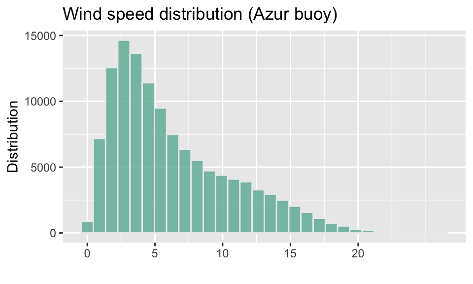

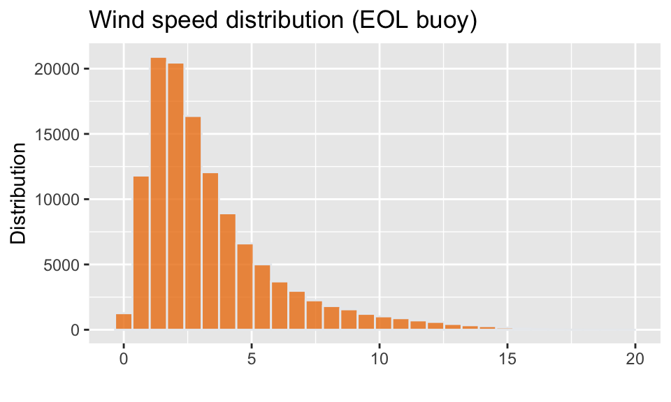

## Annual means of wind speed (2009-2022) : EOL buoy

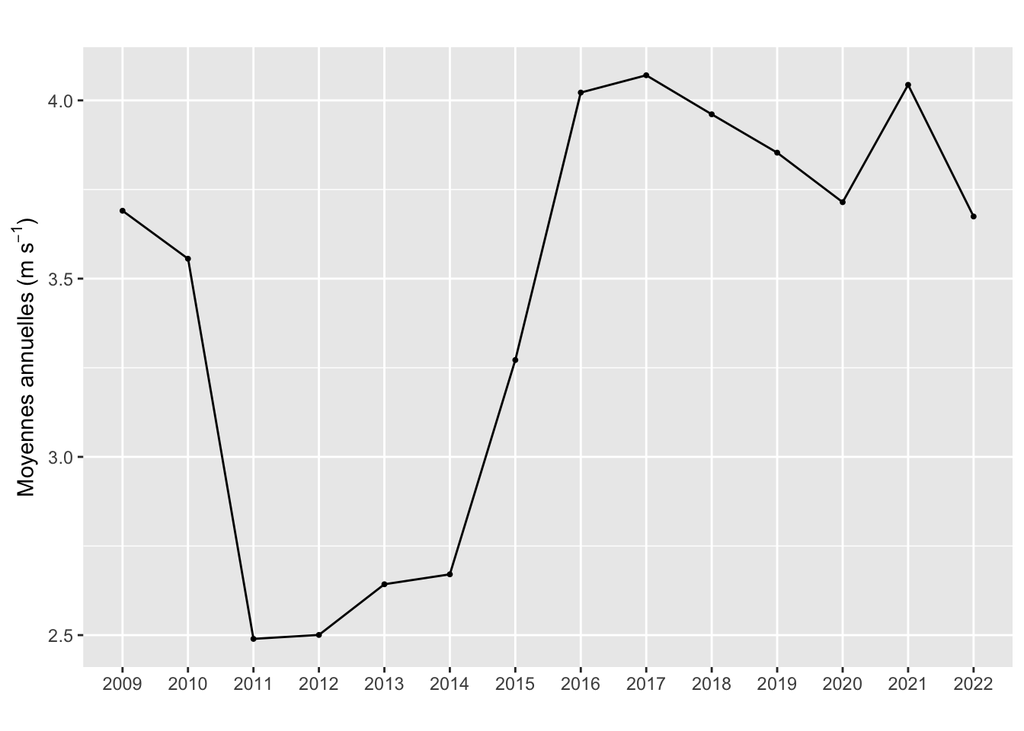

## Data pCO2 water Point B (µatm):

Surface data,  
Frequency : Weekly (every tuesday at 09 AM)  
Unity : µatm

## Annual cycle of seawater pCO<sub>2</sub> at Point B (2007-2022) :

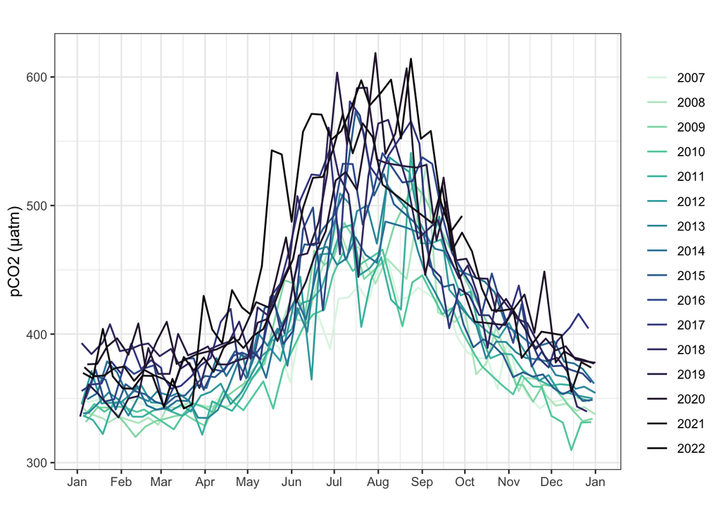

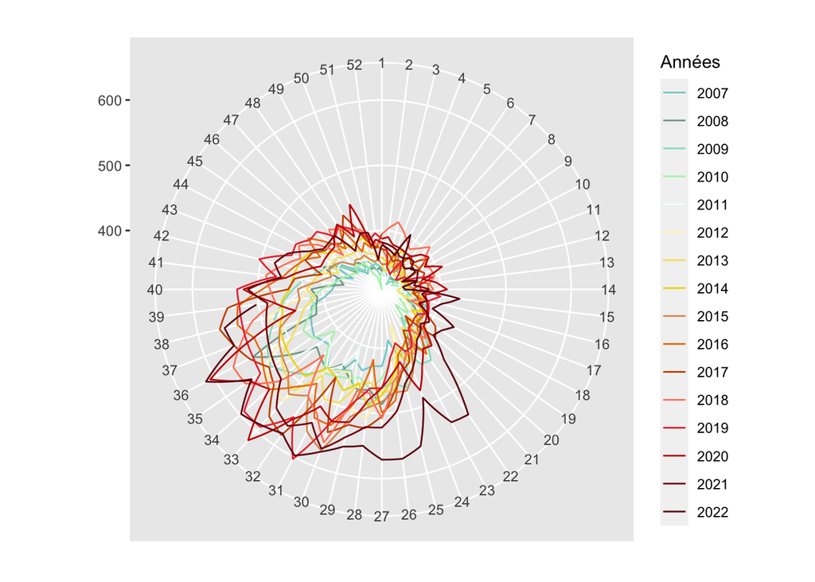

## Calculation of NpCO<sub>2</sub> & TpCO<sub>2</sub> and deltas :

NpCO<sub>2</sub> = non-temperature effects on pCO<sub>2</sub> water variations

TpCO<sub>2</sub> = only temperature effects on pCO<sub>2</sub> water variations

→ Calculation of deltas :

- delta pCO<sub>2</sub>(T) = temperature effects = pCO<sub>2</sub> water - NpCO<sub>2</sub>
- delta pCO<sub>2</sub>(bio) : biological effects = pCO<sub>2</sub> water - TpCO<sub>2</sub>

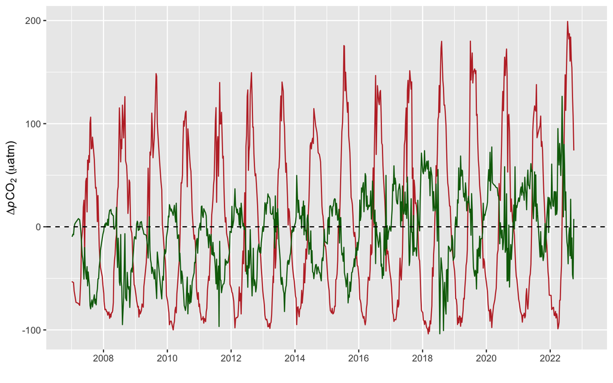

## Atmospheric and seawater pCO<sub>2</sub> (µatm) according to time (2007-2022) :

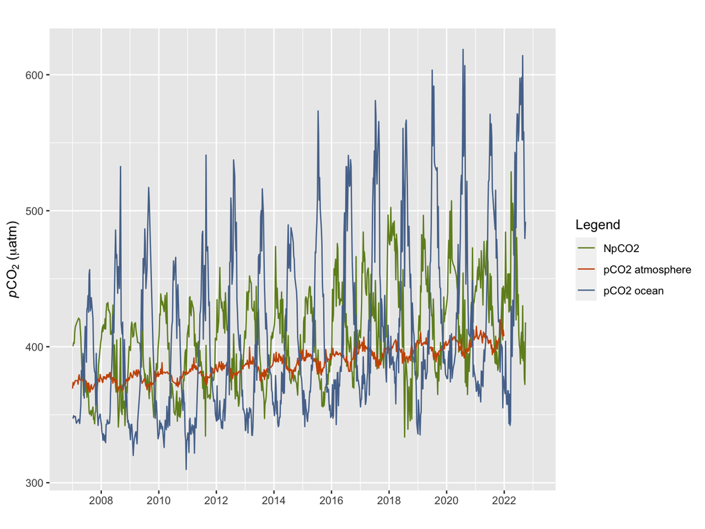

## Air-sea CO<sub>2</sub> fluxes

### Flux calculation

→ **negative values = flux into the ocean**

Method used : Wanninkhof (2014)

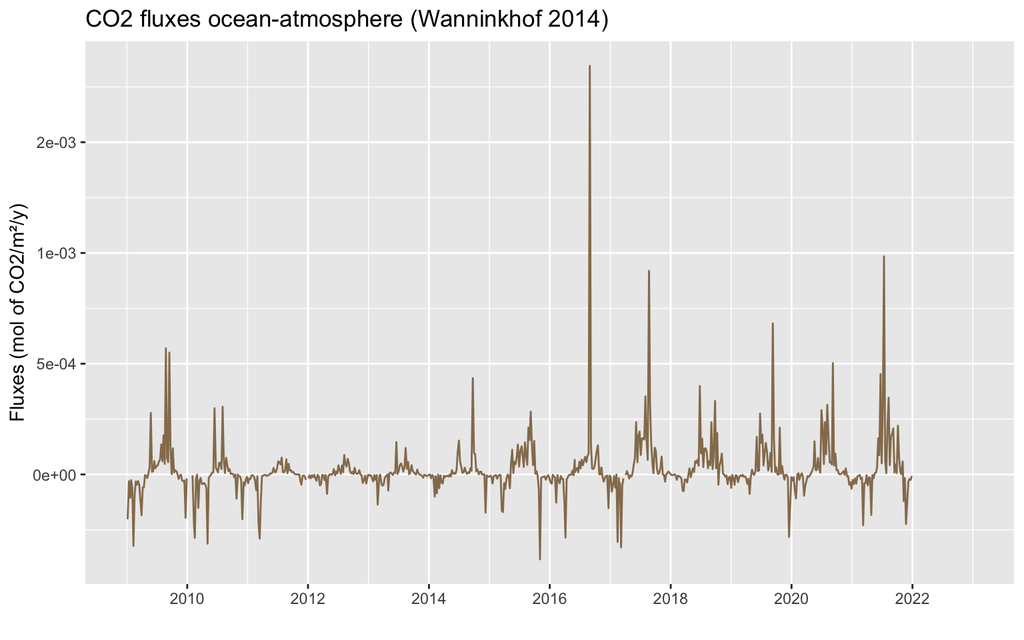

Method used : Wanninkhof (1992)

Formulas :

- K600 = 0.266 * U²
- SC = 2073.1 - (125.62 * T) + (3.6276 * T²) - (0.043219 * T^3)
- k = K600 * (SC/600)^0.5 (cm/h)
- K0 = Henry’s constant (seacarb)

Final formula : F = k * K0 * ΔpCO2

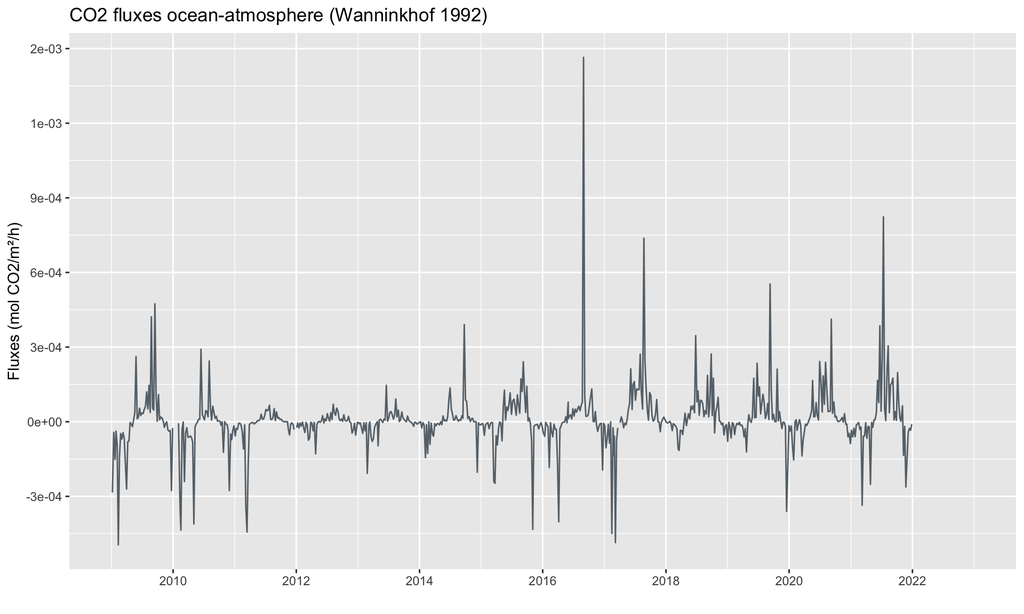

### Plot comparing the 2 CO<sub>2</sub> fluxes :

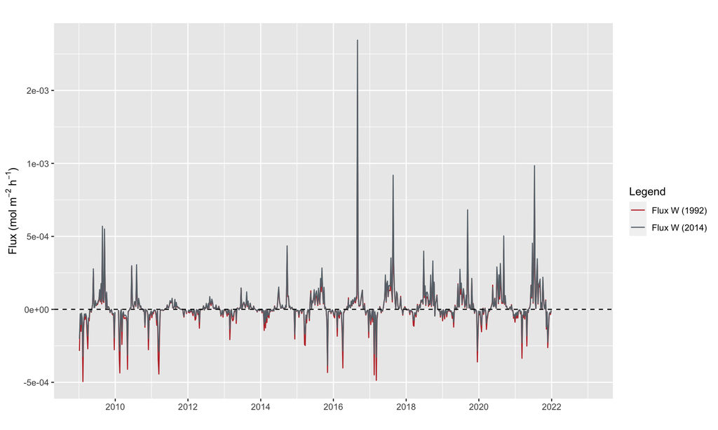

### Annual fluxes (Wanninkhof, 2014)

```
## [1] 0.1390504
```

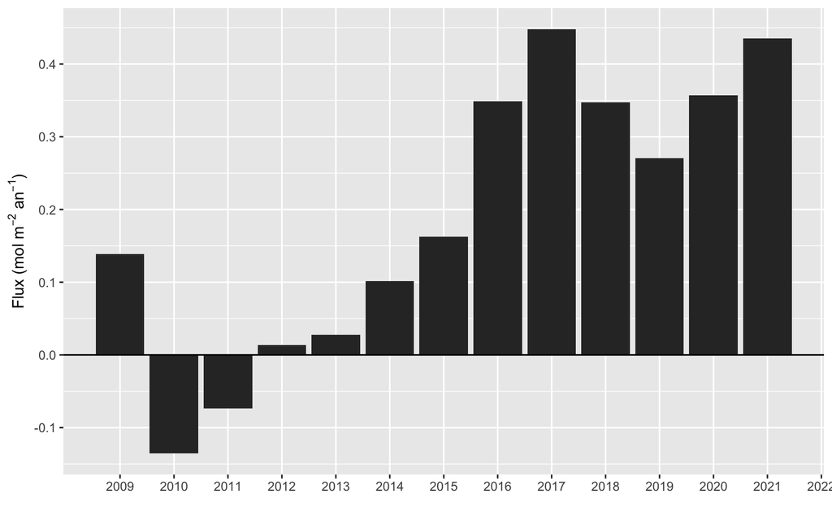

## Comparison with DE CARLO results (jan.2007 - oct.2011)

Point B : 2009-2011, so comparison for 2009-2011 period

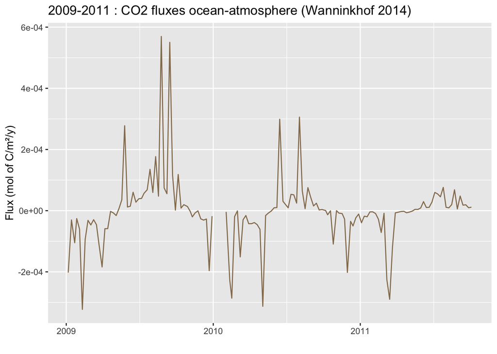

```
## [1] -1.649429e-06
```

De Carlo (2007-2011) :  
- average hourly flux : -2.19e-05  
- annualized flux (by year) : -1.91e-01  
- maximum hourly flux (winter) : -4.57e-04  
- minimum hourly flux (summer): 4.29e-04